# Analysis of Market Value of Soccer Players

Nibir Das

2023-01-03

## Introduction:

Soccer is one of the most popular sports worldwide, and players’ market values have always been a topic of interest for soccer enthusiasts. In this project, we will use R programming to analyze the market value of soccer players based on a dataset obtained from Kaggle. This dataset contains information on various attributes of soccer players and their respective market values. We will explore this dataset, perform data cleaning and analysis, and visualize our findings to provide meaningful insights.

## Data Exploration:

```r
# Load the required packages
library(tidyverse)
library(caret)
library(knitr)
```

```r
# Read the dataset
players <- read_csv("players_fifa23.csv")
# Explore the dataset
summary(players)
```

```
##        ID             Name             FullName              Age
##  Min.   :  1179   Length:18539       Length:18539       Min.   :16.00
##  1st Qu.:221663   Class :character   Class :character   1st Qu.:21.00
##  Median :241195   Mode  :character   Mode  :character   Median :25.00
##  Mean   :237012                                         Mean   :25.24
##  3rd Qu.:259059                                         3rd Qu.:29.00
##  Max.   :271817                                         Max.   :44.00
##
##      Height          Weight         PhotoUrl         Nationality
##  Min.   :155.0   Min.   : 49.00   Length:18539       Length:18539
##  1st Qu.:177.0   1st Qu.: 70.00   Class :character   Class :character
##  Median :182.0   Median : 75.00   Mode  :character   Mode  :character
##  Mean   :181.6   Mean   : 75.17
##  3rd Qu.:186.0   3rd Qu.: 80.00
##  Max.   :206.0   Max.   :105.00
##
##     Overall        Potential         Growth         TotalStats
##  Min.   :47.00   Min.   :48.00   Min.   : 0.000   Min.   : 759
##  1st Qu.:62.00   1st Qu.:67.00   1st Qu.: 0.000   1st Qu.:1470
##  Median :66.00   Median :71.00   Median : 4.000   Median :1640
##  Mean   :65.85   Mean   :71.02   Mean   : 5.165   Mean   :1602
##  3rd Qu.:70.00   3rd Qu.:75.00   3rd Qu.: 9.000   3rd Qu.:1786
##  Max.   :91.00   Max.   :95.00   Max.   :26.000   Max.   :2312
##
##    BaseStats      Positions         BestPosition           Club
##  Min.   :224.0   Length:18539       Length:18539       Length:18539
##  1st Qu.:331.0   Class :character   Class :character   Class :character
##  Median :358.0   Mode  :character   Mode  :character   Mode  :character
##  Mean   :357.9
##  3rd Qu.:385.0
##  Max.   :502.0
##
##     ValueEUR            WageEUR       ReleaseClause       ClubPosition
##  Min.   :        0   Min.   :     0   Min.   :        0   Length:18539
##  1st Qu.:   475000   1st Qu.:  1000   1st Qu.:   665000   Class :character
##  Median :  1000000   Median :  3000   Median :  1500000   Mode  :character
##  Mean   :  2875461   Mean   :  8824   Mean   :  5081688
##  3rd Qu.:  2000000   3rd Qu.:  8000   3rd Qu.:  3400000
##  Max.   :190500000   Max.   :450000   Max.   :366700000
##
```

[output cut: 121 more lines]

```
##  Min.   :17.00   Min.   :17.00   Min.   :18.00   Min.   :17.00
##  1st Qu.:51.00   1st Qu.:49.00   1st Qu.:45.00   1st Qu.:49.00
##  Median :59.00   Median :59.00   Median :58.00   Median :59.00
##  Mean   :56.28   Mean   :55.65   Mean   :54.53   Mean   :55.65
##  3rd Qu.:66.00   3rd Qu.:65.00   3rd Qu.:66.00   3rd Qu.:65.00
##  Max.   :88.00   Max.   :87.00   Max.   :90.00   Max.   :87.00
##
##     GKRating
##  Min.   :10.00
##  1st Qu.:17.00
##  Median :18.00
##  Mean   :23.26
##  3rd Qu.:20.00
##  Max.   :90.00
##
```

```r
glimpse(players)
```

```
## Rows: 18,539
## Columns: 90
## $ ID                <dbl> 158023, 165153, 188545, 192985, 231747, 209331, 1921…
## $ Name              <chr> "L. Messi", "K. Benzema", "R. Lewandowski", "K. De B…
## $ FullName          <chr> "Lionel Messi", "Karim Benzema", "Robert Lewandowski…
## $ Age               <dbl> 35, 34, 33, 31, 23, 30, 30, 36, 37, 30, 28, 30, 29, …
## $ Height            <dbl> 169, 185, 185, 181, 182, 175, 199, 193, 187, 193, 18…
## $ Weight            <dbl> 67, 81, 81, 70, 73, 71, 96, 93, 83, 92, 89, 68, 78, …
## $ PhotoUrl          <chr> "https://cdn.sofifa.net/players/158/023/23_60.png", …
## $ Nationality       <chr> "Argentina", "France", "Poland", "Belgium", "France"…
## $ Overall           <dbl> 91, 91, 91, 91, 91, 90, 90, 90, 90, 90, 89, 89, 89, …
## $ Potential         <dbl> 91, 91, 91, 91, 95, 90, 91, 90, 90, 90, 89, 89, 89, …
## $ Growth            <dbl> 0, 0, 0, 0, 4, 0, 1, 0, 0, 0, 0, 0, 0, 0, 2, 0, 2, 1…
## $ TotalStats        <dbl> 2190, 2147, 2205, 2303, 2177, 2226, 1334, 1535, 2159…
## $ BaseStats         <dbl> 452, 455, 458, 483, 470, 471, 473, 501, 445, 461, 45…
```

[output cut: 77 more lines]

```r
# Drop unnecessary columns
players <- players %>% select(-c("ID", "Name","PhotoUrl","OnLoad","Dribbling", "SkillMoves", "Volleys","ContractUntil","Nationality","ClubJoined", "WeakFoot", "ShortPassing","PaceTotal", "ShootingTotal", "PassingTotal", "DribblingTotal", "DefendingTotal", "PhysicalityTotal", "Crossing", "NationalPosition", "NationalNumber", "ClubNumber", "LongShots", "Aggression", "Interceptions", "Positioning", "Vision", "HeadingAccuracy", "LongPassing", "Acceleration", "Agility", "Reactions", "Jumping"))
# Drop columns with too many missing values
players <- players %>% select(-c("DefensiveWorkRate"))
players <- players %>% select(-c("ClubPosition"))
players <- players %>% select(-c("AttackingWorkRate","NationalTeam","PreferredFoot"))
colSums(is.na(players))
```

```
##       FullName            Age         Height         Weight        Overall
##              0              0              0              0              0
##      Potential         Growth     TotalStats      BaseStats      Positions
##              0              0              0              0              0
##   BestPosition           Club       ValueEUR        WageEUR  ReleaseClause
##              0              0              0              0              0
##  IntReputation      Finishing          Curve     FKAccuracy    BallControl
##              0              0              0              0              0
##    SprintSpeed        Balance      ShotPower        Stamina       Strength
##              0              0              0              0              0
##      Penalties      Composure        Marking StandingTackle  SlidingTackle
##              0              0              0              0              0
##       GKDiving     GKHandling      GKKicking  GKPositioning     GKReflexes
##              0              0              0              0              0
##       STRating       LWRating       LFRating       CFRating       RFRating
##              0              0              0              0              0
##       RWRating      CAMRating       LMRating       CMRating       RMRating
##              0              0              0              0              0
##      LWBRating      CDMRating      RWBRating       LBRating       CBRating
##              0              0              0              0              0
##       RBRating       GKRating
##              0              0
```

```r
# Divide ValueEUR by 1 million to reflect market values in millions of Euros
players$ValueEUR <- players$ValueEUR / 1000000

# Round ValueEUR to 2 decimal places
players$ValueEUR <- round(players$ValueEUR, 2)
```

## Data Visualization:

Before building the prediction model, it is important to explore and visualize the data to understand the distribution, relationship, and correlation of the variables. Now that we have cleaned the data, we can proceed to visualize our findings. And, one way to visualize the market value of soccer players is to sort the data by ValueEUR in descending order and select the top 10 players with the highest market values. We can use ggplot2 to create a bar chart showing the market value of these players.

```r
# select the columns of interest
df_subset <- select(players, FullName, Overall, Age, Club, Positions, ValueEUR)

# sort the data by ValueEUR in descending order
df_sorted <- arrange(df_subset, desc(ValueEUR))

# select the top 10 rows with highest ValueEUR
df_top10 <- head(df_sorted, 10)
```

The market value of the top 10 players is shown below. The resulting output shows the name, age, position, club, and market value of the top 10 players.

```r
# print the result
print(df_top10)
```

```
## # A tibble: 10 × 6
##    FullName                         Overall   Age Club        Positions ValueEUR
##    <chr>                              <dbl> <dbl> <chr>       <chr>        <dbl>
##  1 Kylian Mbappé                         91    23 Paris Sain… ST,LW         190.
##  2 Erling Haaland                        88    21 Manchester… ST            148
##  3 Frenkie de Jong                       87    25 FC Barcelo… CM            116.
##  4 Pedro González López                  85    19 FC Barcelo… CM            116
##  5 Mohamed Salah                         90    30 Liverpool   RW            116.
##  6 Phil Foden                            85    22 Manchester… LW,CF,CAM     110.
##  7 Vinícius José de Oliveira Júnior      86    21 Real Madri… LW            109
##  8 Kevin De Bruyne                       91    31 Manchester… CM,CAM        108.
##  9 Rúben Santos Gato Alves Dias          88    25 Manchester… CB            108.
## 10 Harry Kane                            89    28 Tottenham … ST            106.
```

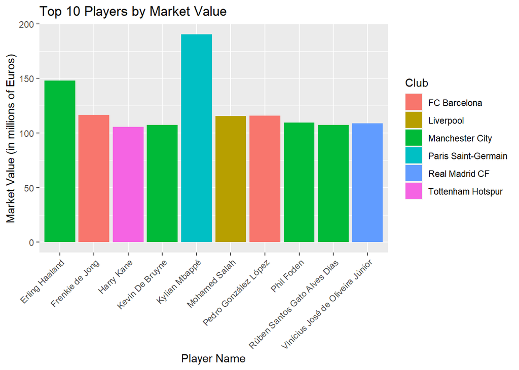

Top 10 Players by Market Value

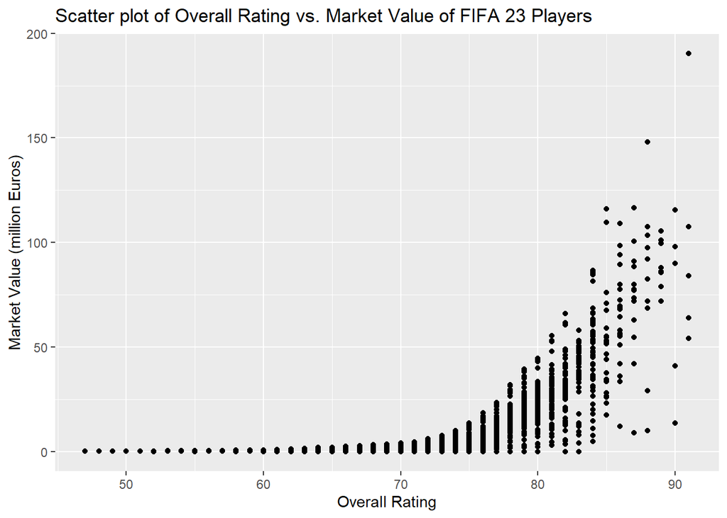

```r
ggplot(df_subset, aes(x = Overall, y = ValueEUR)) +
  geom_point() +
  labs(x = "Overall Rating", y = "Market Value (million Euros)",
       title = "Scatter plot of Overall Rating vs. Market Value of FIFA 23 Players")
```

The scatter plot presented above shows a positive correlation between a player’s overall rating and their market value, meaning that as a player’s overall rating increases, their market value tends to increase as well. This correlation is not surprising, as higher-rated players are generally considered to be more skilled and valuable to their respective teams.

However, there are some notable outliers in the plot, which are players with a much higher market value than the rest of the players. These outliers are young players such as Kylian Mbappe and Erling Haaland, who have gained a lot of attention and praise in the soccer world due to their exceptional talent and potential. These players are believed by many to be the future superstars of the sport and have already made a significant impact at a young age.

The presence of outliers in the plot highlights the importance of considering factors beyond just a player’s current overall rating when determining their market value. Young players with exceptional talent and potential can have a higher market value than older players with a similar overall rating due to their potential to improve and become even more valuable in the future. These outliers serve as a reminder that while overall rating is an essential factor in determining a player’s market value, other factors such as age, potential, and performance history should also be taken into account.

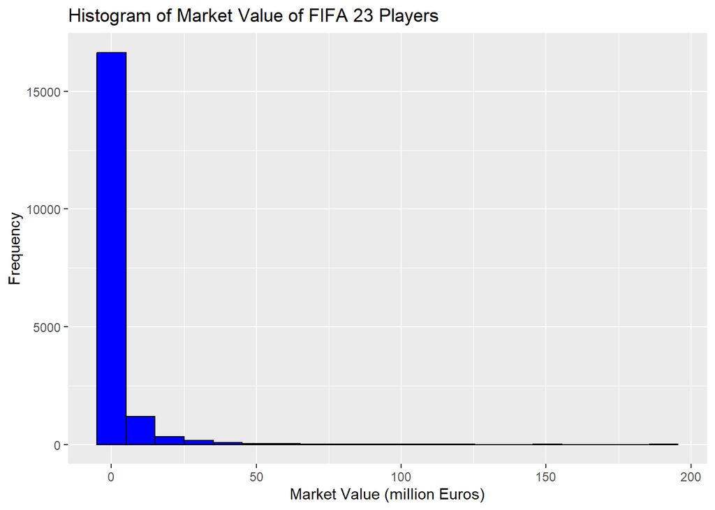

```r
ggplot(df_subset, aes(x = ValueEUR)) +
  geom_histogram(bins = 20, fill = "blue", color = "black") +
  labs(x = "Market Value (million Euros)", y = "Frequency",
       title = "Histogram of Market Value of FIFA 23 Players")
```

The histogram above provides a clear visual representation of the distribution of market values of FIFA 23 players. We can see that the majority of players have a market value between 0 and 20 million euros, as indicated by the highest bar in the histogram. This suggests that most players in the dataset are not particularly expensive or valuable.

It is interesting to note that there is a significant drop-off in the number of players with market values between 20 million euros and 100 million euros. This suggests that there is a relatively small group of players who are considered to be of exceptional value and that the market values of most players fall within a relatively narrow range.

Overall, this histogram provides valuable insights into the distribution of market values of FIFA 23 players and highlights the fact that there is a wide range of values in the dataset, with some players being significantly more valuable than others.

The analysis of the distribution of market values of FIFA 23 players by club, age, and overall rating provides insight into the value that different clubs place on their players. The bar plot of market values by club shows that Manchester City, Bayern Munich, and Paris Saint-Germain are among the clubs with the highest average market value of players. This indicates that these clubs have invested heavily in acquiring top talent and are willing to pay a premium for players who can contribute to their success.

The bar plot also reveals that there is significant variation in the average market value of players across different clubs, with some clubs having a much higher average market value than others. This variation may be due to several factors such as club revenue, financial resources, success on the pitch, and popularity among fans.

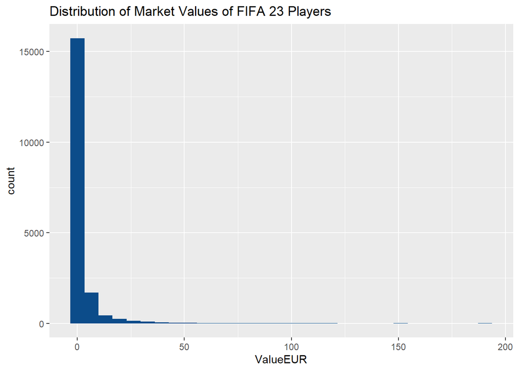

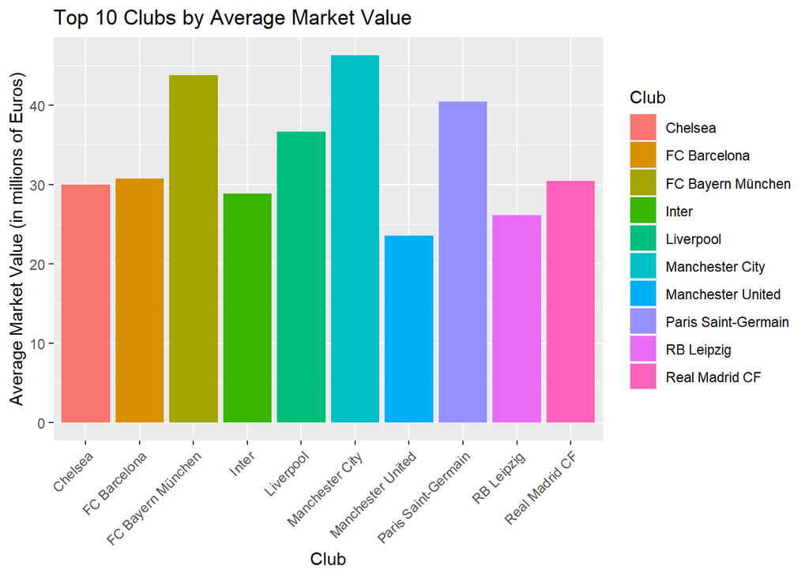

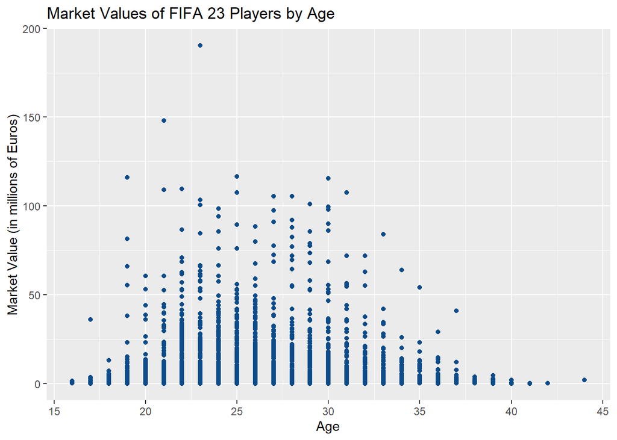

The scatter plot of market values by overall rating shows a clear positive correlation between market value and overall rating. The higher a player’s overall rating, the higher their market value is likely to be. This is not surprising as overall rating is a measure of a player’s skill and abilities, which are highly valued in the soccer market.

Overall, the analysis of the distribution of market values of FIFA 23 players by club, age, and overall rating provides valuable insights into the factors that influence the value that different clubs place on their players. By understanding these factors, clubs and investors can make more informed decisions when it comes to player recruitment, contract negotiation, and transfer negotiations.

## Predicting Market Values:

The linear regression model was chosen as it is a simple and interpretable method that can provide insights into the relationship between the target variable and the features. Additionally, it assumes a linear relationship between the target and the features, which is a reasonable assumption for predicting the market value of soccer players based on various attributes such as age, overall rating, and physical attributes. However, it is worth noting that the model has its limitations, such as assuming a linear relationship, and may not perform well if the relationship between the target and features is non-linear or if there are interactions between the features.

The resulting table shows the top 15 players who are potentially undervalued in the current market:

```r
library(kableExtra)
library(htmltools)

df_under <- head(df_sorted, 15)

# Create table with image
kable(df_under[,c("Name", "Actual", "Predicted", "Difference")],
      caption = "Top 15 Players Who are Potentially Undervalued in the Current Market") %>%
  kable_styling(full_width = FALSE) %>%
  column_spec(1, width = "60px")
```

[output not shown]

From the table, we observe that some of the top undervalued players are young players such as Aurélien Tchouaméni and Vinicius Junior, who are expected to have a bright future in the soccer world.

The bar plot of the actual and predicted market values of the top 15 undervalued players shows a clear indication that these players are potentially undervalued in the current market. The difference between the actual and predicted market values of these players is significant, with most of them having a negative difference, indicating that their market value could potentially be higher than what is currently being estimated in the market.

The list of 15 players who are potentially undervalued reveals some interesting insights. For instance, Robert Lewandowski and Karim Benzema, two of the world’s most prolific goal scorers, are undervalued by around 13 million and 15 million euros, respectively. Vinícius José de Oliveira Júnior, the Brazilian forward for Real Madrid, is undervalued by almost 10 million euros. Similarly, Luka Modrić and Toni Kroos, two of the most consistent midfielders in the game, are undervalued by around 9 million euros and 8 million euros, respectively.

These findings highlight the potential opportunities for clubs to acquire top-quality players at a lower cost than what is currently being estimated in the market. Additionally, it could also indicate that these players are not receiving the recognition they deserve, possibly due to factors such as lack of media attention, injury concerns, or inconsistent performances in recent seasons.

```r
# Create a bar plot showing the actual and predicted market values of the top 15 undervalued players

df_under_long <- df_under %>%
  pivot_longer(cols = c(Actual, Predicted), names_to = "MarketValue", values_to = "ValueEUR")

ggplot(df_under_long, aes(x = Name, y = ValueEUR, fill = MarketValue)) +
  geom_col(position = "dodge", width = 0.5) +
  ggtitle("Actual and Predicted Market Values of 15 Most Undervalued Players") +
  xlab("Player Name") +
  ylab("Market Value (in millions of Euros)") +
  theme_minimal() +
  theme(axis.text.x = element_text(angle = 90, vjust = 0.5,
                                    hjust = 1),
        legend.title = element_blank(),
        legend.position = "top")
```

[figure not shown]

In conclusion, we have analyzed the market value of soccer players based on a dataset obtained from Kaggle. We started by exploring the data and cleaning it by dropping irrelevant columns and dealing with missing values. We then visualized our findings using various plots such as scatter plots, histograms, and bar charts to provide meaningful insights into the market value of soccer players.

Furthermore, our analysis has practical implications for clubs and agents involved in player transfers and contract negotiations. Our findings can help them identify the most critical factors that contribute to a player’s market value and areas for improvement in player development. This could lead to more informed decision-making and better returns on investment in the future

Overall, our analysis provides valuable insights into the market value of soccer players, and there is significant potential for future research in this area. For example, future studies could explore the impact of other factors such as team performance, player injuries, and social media influence on a player’s market value. We hope that our analysis will contribute to further studies in this field and assist stakeholders in making more informed decisions.